# SEM ICT and health

Mathijn Wilkens

12 July, 2019

```r
load("data/EWCS_EU28.Rda")
```

# Introduction

Ter Hoeven et al. (2016) suggest a more nuanced view and focus not only on the negative but also on the positive aspects of ICT use, arguing that focusing on job demands only will show negative links between ICT use and health while focusing on job resources only will show positive links. They analyse the effect of ICT use by estimating a JD-R (job demands - resources) model that hypothesises that ICT use enhances effective communication and accessibilty as well as makes work more unpredictable and causes more interruptions. This model is supported by a sample of Dutch employees and also inlcudes links to burnout and engagement, showing that advantages and disadvantages of ICT use are equally strong with regards to burnout while the positive effects on engagements are bigger than the negative effects.

Eurofound (2019) applies a job demands - job resources model on the EWCS and shows how various working conditions hypothesised to be job demands and resources are related to health outcomes. The following analysis buils on this model by including job demands and resources in a model that also includes how ICT usage is related to these. This allows for an broad scoped investigation of the link between ICT and health. The following analysis differs also from Eurofound (2019) because it focuses on the job demands and resources that are more relevant in the context of using ICTs, as found in the literature.

When analying how ICT is associated with health and wellbeing in the EWCS, both positive and negative pathways are taken into account. The goal is to estimate a structural equation model that measures the effect of computer use on health outcomes. We are testing the hypothesis that this effect is mediated through both job demands and job resources. From the literature it follows that from what is available in the EWCS; quantitative demands, working time, frequent disruptive interruptions, working in the free time and cognitive demands can be considered relevant job demands. Relevant job resources are autonomy, social support and working time flexibilty. Health and wellbeing in the EWCS is measured by general self-rated health, the WHO-5 mental wellbeing scale, fatigue, anxiety, stress, headaches or eyestrain and absenteeism and presenteeism (working while sick).

The graph below shows the struture of the model that is estimated for this project. The frequency of using computers is hypthesised to have an effect on job demands (above) and job resources (below) which in turn have an effect on a range of health outcomes. Also, we allow for a direct effect of computer use on health outcomes to see if there is still an effect having controlled for all the mediators. It includes (not shown) controls for age, gender, ISCO1, NACE10, education, year and country. These controls are active in the regressions of the effect of computer use on the mediators, as well as the effect of the mediators on the outcomes. The data are from 2010 and 2015.

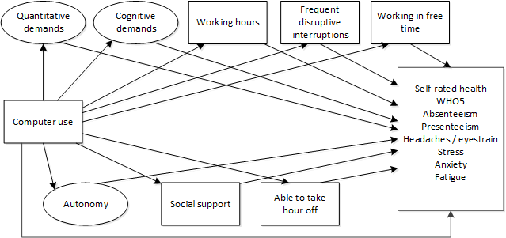

It is important to note that the EWCS is cross sectional data. Although the models assumes a causal structure, we cannot test whether any association is in fact the result of a causal process. Structural equation modelling based on cross sectional data casts doubt on these causal assumptions if the model does not fit the data and makes them tentatively more plausible otherwise (Bollen and Pearl, 2013).

# Descriptive statistics and index check

The following section shows descriptive statistics of the mediators by computer use as well as the mediators by the health outcomes. Some of these mediators in the model are constructed by means of latent variables. In this part several indexes or latent variables are created that will feed into the model. These latent variables are checked first to see if they have a good fit and reliability. Sometimes this is not possible when they are to small to be identified in an estimation.

## Quantiative demands

To capture quantitative demands, we use the quantitative demands index as formulated in Eurofound (2017). The idea is that computer use will lead to more intensity. It includes the variables working at high speed and tight deadlines.

Questions included:

- Q49a: Does your job involve working at high speed? (Never - … - All of the time)
- Q49b: Does your job involve working to tight deadlines? (Never - … - All of the time)

The fit of the CFA cannot be tested because there are no degrees of freedom left.

```r
QD_m <- 'QD =~ y15_Q49a + y15_Q49b '
```

The chart below shows that quantitative demands follow a U-shaped pattern when plotted by computer use - working at high speed or tight deadlines are most commmon for those who either use computers all of the time or never.

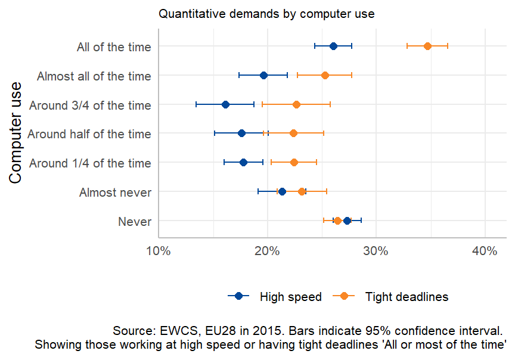

```r
df <- subset(EWCS_EU28, select=c(y15_Q30i,w5_EU28,y15_Q49a,y15_Q49b), year==2015)
df$highspeed <- as.numeric(df$y15_Q49a=="All of the time        " | df$y15_Q49a=="Almost all of the time ")
df$tightdead <- as.numeric(df$y15_Q49b=="All of the time        " | df$y15_Q49b=="Almost all of the time ")

svydes <- svydesign(ids=~1, data=df, weights=~w5_EU28)

df1 <- svyby(~highspeed, ~y15_Q30i, svydes, svymean, na.rm = TRUE)
df1 <- cbind(df1, confint(df1))
df1$value <- df1$highspeed
df1$variable <- "High speed"
df1 <- df1[,-2]

df2 <- svyby(~tightdead, ~y15_Q30i, svydes, svymean, na.rm = TRUE)
df2 <- cbind(df2, confint(df2))
df2$value <- df2$tightdead
df2$variable <- "Tight deadlines"
df2 <- df2[,-2]

df <- rbind(df1,df2)

p <- ggplot(df, aes(x=y15_Q30i, y=value, colour=variable)) +
      geom_errorbar(aes(ymin=`2.5 %`, ymax=`97.5 %`), width=0.2) +
      geom_point(size=2) +
      coord_flip() +
      scale_colour_manual(NULL, values=EF_2c) +
      scale_y_continuous(expand = c(0, 0), limit = c(0.1,0.42), breaks = seq(0.1, 0.4, 0.1), labels = percent_format(accuracy = 1)) +
      labs(title = "Quantitative demands by computer use",
           caption = "Source: EWCS, EU28 in 2015. Bars indicate 95% confidence interval. \nShowing those working at high speed or having tight deadlines 'All or most of the time'",
           x="Computer use",
           y=NULL) +
      theme_minimal(base_size = 10) +
      theme(legend.position="bottom",
            axis.line = element_line(colour="grey"),
            plot.title = element_text(size=8))

p
```

```r
ggsave("Quantitative demands by computer use.eps",
       plot = p + labs(title=NULL,caption=NULL),
       device = "eps", path="charts/",
       scale = 1, width = 8, height = 6, units = "cm")
write.csv(df, file="charts/Quantitative demands by computer use.csv")
```

## Autonomy

The latent variable measuring autonomy is based on Eurofound (2017), except for ‘having a say in the choice of colleagues’ because that lowers model fit (not shown). Having a computer would be a resources that allows for more autonomy in the job, which could in turn be associated with better health outcomes.

Questions included:

- Q54a: Are you able to choose or change your order of tasks? (Y/N)
- Q54b: Are you able to choose or change your methods of work? (Y/N)
- Q54c: Are you able to choose or change your speed or rate of work? (Y/N)

The fit of the CFA cannot be tested because there are no degrees of freedom left. Reliability is looking good however.

```r
AUT_m <- 'AUT =~ y15_Q54a + y15_Q54b + y15_Q54c'

fit <- sem(AUT_m, data=subset(EWCS_EU28,year>=2005))
reliability(fit)
```

```
##              AUT     total
## alpha  0.9058279 0.9058279
## omega  0.7817201 0.7817201
## omega2 0.7817201 0.7817201
## omega3 0.7817201 0.7817201
## avevar 0.7641898 0.7641898
```

The chart below shows autonomy by computer use and shows a positive correlation, although there is little difference after ‘around 1/4th of the time’

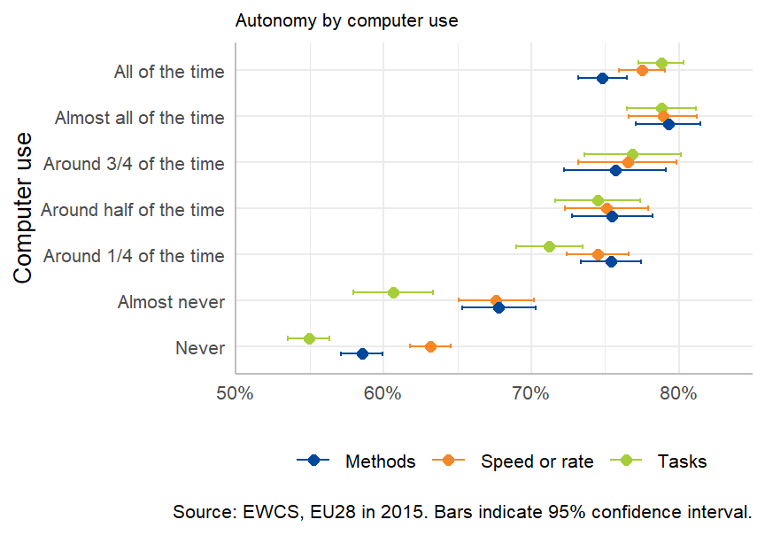

```r
df <- subset(EWCS_EU28, select=c(y15_Q30i,w5_EU28,y15_Q54a,y15_Q54b,y15_Q54c), year==2015)
df$tasks <- as.numeric(df$y15_Q54a)-1
df$methods <- as.numeric(df$y15_Q54b)-1
df$rate <- as.numeric(df$y15_Q54c)-1

svydes <- svydesign(ids=~1, data=df, weights=~w5_EU28)

df1 <- svyby(~tasks, ~y15_Q30i, svydes, svymean, na.rm = TRUE)
df1 <- cbind(df1, confint(df1))
df1$value <- df1$tasks
df1$variable <- "Tasks"
df1 <- df1[,-2]

df2 <- svyby(~methods, ~y15_Q30i, svydes, svymean, na.rm = TRUE)
df2 <- cbind(df2, confint(df2))
df2$value <- df2$methods
df2$variable <- "Methods"
df2 <- df2[,-2]

df3 <- svyby(~rate, ~y15_Q30i, svydes, svymean, na.rm = TRUE)
df3 <- cbind(df3, confint(df3))
df3$value <- df3$rate
df3$variable <- "Speed or rate"
df3 <- df3[,-2]

df <- rbind(df1,df2)
df <- rbind(df,df3)

p <- ggplot(df, aes(x=y15_Q30i, y=value, colour=variable)) +
      geom_errorbar(aes(ymin=`2.5 %`, ymax=`97.5 %`), width=0.3, position = position_dodge(width=0.5)) +
      geom_point(size=2, position = position_dodge(width=0.5)) +
      coord_flip() +
      scale_colour_manual(NULL, values=EF_3c) +
      scale_y_continuous(expand = c(0, 0),
                         limit = c(0.5,0.85),
                         breaks = seq(0.5, 0.85, 0.1),
                         labels = percent_format(accuracy = 1)) +
      labs(title = "Autonomy by computer use",
           caption = "Source: EWCS, EU28 in 2015. Bars indicate 95% confidence interval.",
           x="Computer use",
           y=NULL) +
        theme_minimal(base_size = 10) +
        theme(legend.position="bottom",
            axis.line = element_line(colour="grey"),
            plot.title = element_text(size=8))

p
```

```r
ggsave("Autonomy by computer use.eps",
       plot = p + labs(title=NULL,caption=NULL),
       device = "eps", path="charts/",
       scale = 1, width = 8, height = 6, units = "cm")
write.csv(df, file="charts/Autonomy by computer use.csv")
```

## Cognitive demands

Based on EWCS6 overview report job quality index. It measures the extent to which workers apply their skills in the job and the extent to which they can learn on the job. This would impact their health positively and is seen as a resource. However, we find negative associations with health, so here it is framed as a demand. Cognitive aspects of the job are likely to be a double edged sword - on the one hand they provide the worker with more learning opportunties and interesting work, while on the other hand it also brings more responsibility.

Questions included:

- Q53c: Generally, does your main paid job involve solving unforeseen problems on your own? (Y/N)
- Q53e: Generally, does your main paid job involve complex tasks? (Y/N)
- Q53f: Generally, does your main paid job involve learning new things? (Y/N)

The fit cant be tested in isolation, but when combining it with other models it shows that ‘ability to apply own ideas’ which is originally part of this index does not fit very well so that item is dropped. The reliability is on the low side.

```r
CD_m <- 'CD =~ y15_Q53c + y15_Q53e + y15_Q53f'

fit <- sem(CD_m, data=subset(EWCS_EU28,year>=2005))
reliability(fit)
```

```
##               CD     total
## alpha  0.7862254 0.7862254
## omega  0.6326743 0.6326743
## omega2 0.6326743 0.6326743
## omega3 0.6326743 0.6326743
## avevar 0.5608969 0.5608969
```

Chart shows a positive relation with computer use, although the effect is stronger at the bottom.

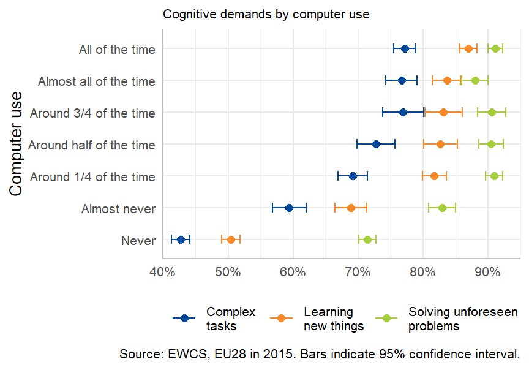

```r
df <- subset(EWCS_EU28, select=c(y15_Q30i,w5_EU28,y15_Q53c,y15_Q53e,y15_Q53f), year==2015)
df$problems <- as.numeric(df$y15_Q53c)-1
df$complex <- as.numeric(df$y15_Q53e)-1
df$newthings <- as.numeric(df$y15_Q53f)-1

svydes <- svydesign(ids=~1, data=df, weights=~w5_EU28)

df1 <- svyby(~problems, ~y15_Q30i, svydes, svymean, na.rm = TRUE)
df1 <- cbind(df1, confint(df1))
df1$value <- df1$problems
df1$variable <- "Solving unforeseen \nproblems"
df1 <- df1[,-2]

df2 <- svyby(~complex, ~y15_Q30i, svydes, svymean, na.rm = TRUE)
df2 <- cbind(df2, confint(df2))
df2$value <- df2$complex
df2$variable <- "Complex \ntasks"
df2 <- df2[,-2]

df3 <- svyby(~newthings, ~y15_Q30i, svydes, svymean, na.rm = TRUE)
df3 <- cbind(df3, confint(df3))
df3$value <- df3$newthings
df3$variable <- "Learning \nnew things"
df3 <- df3[,-2]

df <- rbind(df1,df2)
df <- rbind(df,df3)

p <- ggplot(df, aes(x=y15_Q30i, y=value, colour=variable)) +
      geom_errorbar(aes(ymin=`2.5 %`, ymax=`97.5 %`), width=0.3) +
      geom_point(size=2) +
      coord_flip() +
      scale_colour_manual(NULL, values=EF_3c) +
      scale_y_continuous(expand = c(0, 0),
                         limit = c(0.4,0.95),
                         breaks = seq(0.4, 0.95, 0.1),
                         labels = percent_format(accuracy = 1)) +
      labs(title = "Cognitive demands by computer use",
           caption = "Source: EWCS, EU28 in 2015. Bars indicate 95% confidence interval.",
           x="Computer use",
           y=NULL) +
      theme_minimal(base_size = 10) +
      theme(legend.position="bottom",
            axis.line = element_line(colour="grey"),
            plot.title = element_text(size=8))

p
```

```r
ggsave("Cognitive demands by computer use.eps",
       plot = p + labs(title=NULL,caption=NULL),
       device = "eps", path="charts/",
       scale = 1, width = 8, height = 6, units = "cm")
write.csv(df, file="charts/cognitive demands by computer use.csv")
```

## Social support

Social support is a latent variable that is measured by two questions:

- Q61a: Your colleagues help and support you (Never - … - Always)
- Q61b: Your manager helps and supports you (Never - … - Always)

Chart below shows a positive association of computer use and social support. Again, the correlation is mostly concentrated around the bottom.

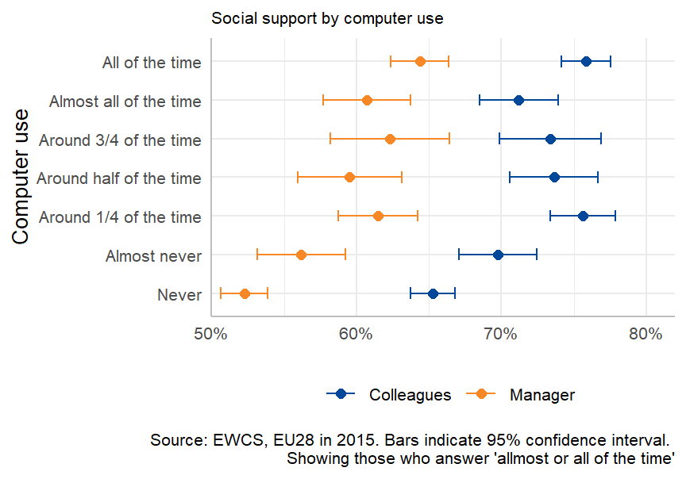

```r
df <- subset(EWCS_EU28, select=c(y15_Q30i,w5_EU28,y15_Q61a,y15_Q61b), year==2015)
df$colleagues <- as.numeric(df$y15_Q61a=="Most of the time             " | df$y15_Q61a=="Always                       ")
df$manager    <- as.numeric(df$y15_Q61b=="Most of the time             " | df$y15_Q61b=="Always                       ")

svydes <- svydesign(ids=~1, data=df, weights=~w5_EU28)

df1 <- svyby(~colleagues, ~y15_Q30i, svydes, svymean, na.rm = TRUE)
df1 <- cbind(df1, confint(df1))
df1$value <- df1$colleagues
df1$variable <- "Colleagues"
df1 <- df1[,-2]

df2 <- svyby(~manager, ~y15_Q30i, svydes, svymean, na.rm = TRUE)
df2 <- cbind(df2, confint(df2))
df2$value <- df2$manager
df2$variable <- "Manager"
df2 <- df2[,-2]

df <- rbind(df1,df2)

p <- ggplot(df, aes(x=y15_Q30i, y=value, colour=variable)) +
      geom_errorbar(aes(ymin=`2.5 %`, ymax=`97.5 %`), width=0.3) +
      geom_point(size=2) +
      coord_flip() +
      scale_colour_manual(NULL, values=EF_2c) +
      scale_y_continuous(expand = c(0, 0),
                         limit = c(0.5,0.82),
                         breaks = seq(0.5, 0.8, 0.1),
                         labels = percent_format(accuracy = 1)) +
      labs(title = "Social support by computer use",
           caption = "Source: EWCS, EU28 in 2015. Bars indicate 95% confidence interval. \nShowing those who answer 'allmost or all of the time'",
           x="Computer use",
           y=NULL) +
      theme_minimal(base_size = 10) +
      theme(legend.position="bottom",
            axis.line = element_line(colour="grey"),
            plot.title = element_text(size=8))

p
```

```r
ggsave("Social support by computer use.eps",
       plot = p + labs(title=NULL,caption=NULL),
       device = "eps", path="charts/",
       scale = 1, width = 8, height = 6, units = "cm")
write.csv(df, file="charts/Social support by computer use.csv")
```

## Working hours

Positive relation between working hours and ICT use, again most strong correlation at the bottom.

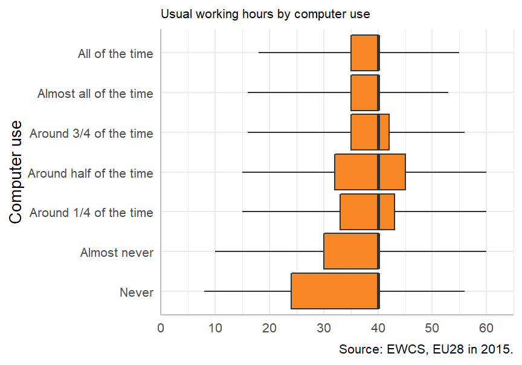

```r
df <- subset(EWCS_EU28, select=c(y15_Q30i,w5_EU28,totalhour), year==2015)

svydes <- svydesign(ids=~1, data=df, weights=~w5_EU28)

df <- svyby(~totalhour, ~y15_Q30i, svydes, svyquantile, quantiles=c(.05,.25,.50,.75,.95), na.rm = TRUE, keep.var=FALSE)

p <- ggplot(df) +
      geom_boxplot(aes(x = y15_Q30i,
                       lower = statistic2,
                       middle=statistic3,
                       upper=statistic4,
                       ymin=statistic1,
                       ymax=statistic5),
                    stat="identity", fill=EF_orange) +
      coord_flip() +
      scale_y_continuous(expand = c(0, 0),
                         limit = c(0,65),
                         breaks = seq(0, 60, 10)) +
      labs(title = "Usual working hours by computer use",
           caption = "Source: EWCS, EU28 in 2015.",
           x="Computer use",
           y=NULL) +
      theme_minimal(base_size = 10) +
      theme(legend.position="bottom",
            axis.line = element_line(colour="grey"),
            plot.title = element_text(size=8))

p
```

```r
colnames(df)[-1] <- c("5%","25%","50%","75%","95%")

ggsave("Working hours by computer use.eps",
       plot = p + labs(title=NULL,caption=NULL),
       device = "eps", path="charts/",
       scale = 1, width = 8, height = 5, units = "cm")
write.csv(df, file="charts/Working hours by computer use.csv")
```

## Frequent disruptive interruptions

Shows a positive correlation in a quite linear way.

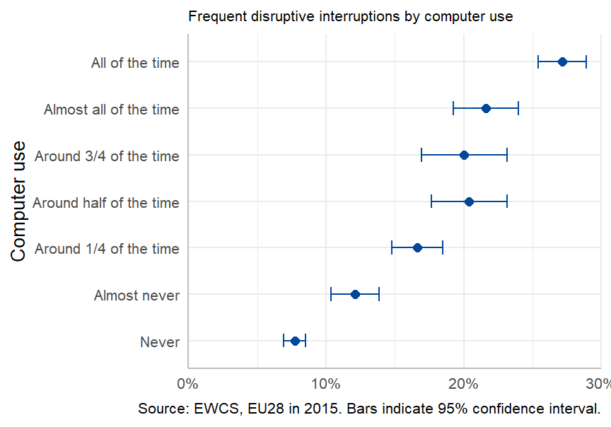

```r
df <- subset(EWCS_EU28, select=c(y15_Q30i,w5_EU28,freq_dis_int), year==2015)
df$freq_dis_int <- as.numeric(df$freq_dis_int)-1

svydes <- svydesign(ids=~1, data=df, weights=~w5_EU28)

df1 <- svyby(~freq_dis_int, ~y15_Q30i, svydes, svymean, na.rm = TRUE)
df1 <- cbind(df1, confint(df1))
df1$value <- df1$freq_dis_int
df1$variable <- "freq_dis_int"
df <- df1[,-2]

p <- ggplot(df, aes(x=y15_Q30i, y=value)) +
      geom_errorbar(aes(ymin=`2.5 %`, ymax=`97.5 %`), width=0.3, colour=EF_blue) +
      geom_point(size=2, colour=EF_blue) +
      coord_flip() +
      scale_y_continuous(expand = c(0, 0),
                         limit = c(0.0,0.3),
                         breaks = seq(0.0, 0.3, 0.1),
                         labels = percent_format(accuracy = 1)) +
      labs(title = "Frequent disruptive interruptions by computer use",
           caption = "Source: EWCS, EU28 in 2015. Bars indicate 95% confidence interval.",
           x="Computer use",
           y=NULL) +
      theme_minimal(base_size = 10) +
      theme(legend.position="bottom",
            axis.line = element_line(colour="grey"),
            plot.title = element_text(size=8))

p
```

```r
ggsave("Frequent disruptive interruptions by computer use.eps",
       plot = p + labs(title=NULL,caption=NULL),
       device = "eps", path="charts/",
       scale = 1, width = 8, height = 5, units = "cm")
write.csv(df, file="charts/Frequent disruptive interruptions by computer use.csv")
```

## Working in free time

The question in the EWCS is: “Over the last 12 months, how often have you worked in your free time to meet work demands?”. It shows a positive correlation, although mostly between ‘never’ and ‘almost never’ and the rest.

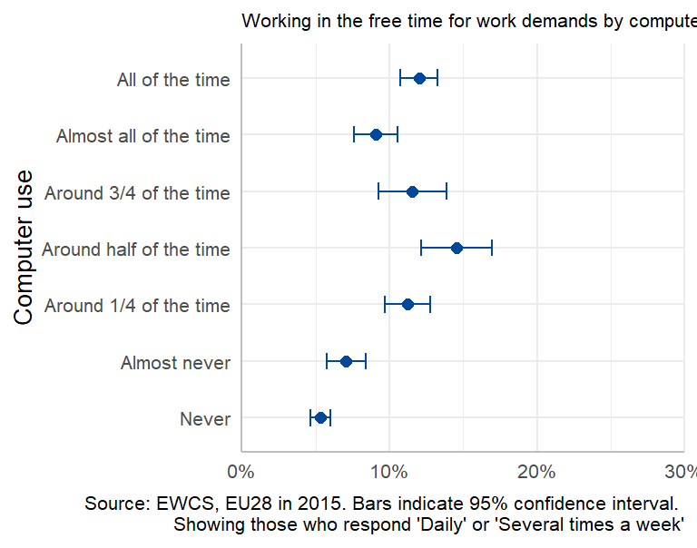

```r
df <- subset(EWCS_EU28, select=c(y15_Q30i,w5_EU28,y15_Q46), year==2015)
df$freetime <- as.numeric(df$y15_Q46=="Daily                        " | df$y15_Q46=="Several times a week         ")

svydes <- svydesign(ids=~1, data=df, weights=~w5_EU28)

df1 <- svyby(~freetime, ~y15_Q30i, svydes, svymean, na.rm = TRUE)
df1 <- cbind(df1, confint(df1))
df1$value <- df1$freetime
df1$variable <- "Working in free time"
df <- df1[,-2]

p <- ggplot(df, aes(x=y15_Q30i, y=value)) +
      geom_errorbar(aes(ymin=`2.5 %`, ymax=`97.5 %`), width=0.3, colour=EF_blue) +
      geom_point(size=2, colour=EF_blue) +
      coord_flip() +
      scale_y_continuous(expand = c(0, 0),
                         limit = c(0.0,0.3),
                         breaks = seq(0.0, 0.3, 0.1),
                         labels = percent_format(accuracy = 1)) +
      labs(title = "Working in the free time for work demands by computer use",
           caption = "Source: EWCS, EU28 in 2015. Bars indicate 95% confidence interval. \nShowing those who respond 'Daily' or 'Several times a week'",
           x="Computer use",
           y=NULL) +
      theme_minimal(base_size = 10) +
      theme(legend.position="bottom",
            axis.line = element_line(colour="grey"),
            plot.title = element_text(size=8))
p
```

```r
ggsave("Working in the free time for work demands by computer use.eps",
       plot = p + labs(title=NULL,caption=NULL),
       device = "eps", path="charts/",
       scale = 1, width = 8, height = 5, units = "cm")
write.csv(df, file="charts/Working in the free time for work demands by computer use.csv")
```

## Able to take an hour off

The question in the EWCS is ‘Would you say that for you arranging to take an hour or two off during working hours to take care of personal or family matters is…?’. The chart below shows a positive correlation between computer use and this question. The relationship seems to be quite linear.

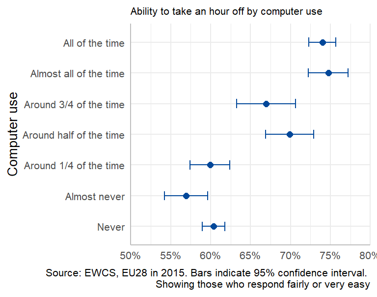

```r
df <- subset(EWCS_EU28, select=c(y15_Q30i,w5_EU28,y15_Q47), year==2015)
df$able <- as.numeric(df$y15_Q47=="Fairly easy                 " | df$y15_Q47=="Very easy                   ")

svydes <- svydesign(ids=~1, data=df, weights=~w5_EU28)

df1 <- svyby(~able, ~y15_Q30i, svydes, svymean, na.rm = TRUE)
df1 <- cbind(df1, confint(df1))
df1$value <- df1$able
df1$variable <- "Able to take an hour off"
df <- df1[,-2]

p <- ggplot(df, aes(x=y15_Q30i, y=value)) +
      geom_errorbar(aes(ymin=`2.5 %`, ymax=`97.5 %`), width=0.3, colour=EF_blue) +
      geom_point(size=2, colour=EF_blue) +
      coord_flip() +
      scale_y_continuous(expand = c(0, 0),
                         limit = c(0.5,0.8),
                         breaks = seq(0.5, 0.8, 0.05),
                         labels = percent_format(accuracy = 1)) +
      labs(title = "Ability to take an hour off by computer use",
           caption = "Source: EWCS, EU28 in 2015. Bars indicate 95% confidence interval. \nShowing those who respond fairly or very easy",
           x="Computer use",
           y=NULL) +
      theme_minimal(base_size = 10) +
      theme(legend.position="bottom",
            axis.line = element_line(colour="grey"),
            plot.title = element_text(size=8))

p
```

```r
ggsave("Ability to take an hour off by computer use.eps",
       plot = p + labs(title=NULL,caption=NULL),
       device = "eps", path="charts/",
       scale = 1, width = 8, height = 5, units = "cm")
write.csv(df, file="charts/Ability to take an hour off by computer use.csv")
```

## WHO5

Turning now to the health outcomes. WHO-5 is the measurement of mental wellbeing and is considered as an outcome variable in this analysis. The data fits the CFA very well and the index shows a high degree of reliability.

```r
WHO5 <- 'WHO5 =~ y15_Q87a + y15_Q87b + y15_Q87c + y15_Q87d + y15_Q87e'

fit <- sem(WHO5, data=subset(EWCS_EU28,year>=2005))
reliability(fit)
```

```
##             WHO5     total
## alpha  0.9047375 0.9047375
## omega  0.8824615 0.8824615
## omega2 0.8824615 0.8824615
## omega3 0.8854592 0.8854592
## avevar 0.6614134 0.6614134
```

The chart below shows there is hardly any difference in WHO5 by computer use. So we wouldn’t expect to find strong effects of computer use on WHO5, mediated or not.

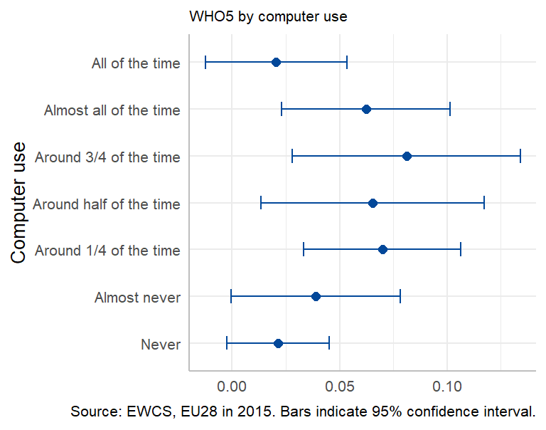

```r
idx <- lavInspect(fit,"case.idx")
scores <- lavPredict(fit)
df <- subset(EWCS_EU28,year>=2005)
df[idx,"WHO5"] <- scores[,"WHO5"]

df <- subset(df, select=c(y15_Q30i,w5_EU28,WHO5), year==2015)

svydes <- svydesign(ids=~1, data=df, weights=~w5_EU28)

df1 <- svyby(~WHO5, ~y15_Q30i, svydes, svymean, na.rm = TRUE)
df1 <- cbind(df1, confint(df1))
df1$value <- df1$WHO5
df1$variable <- "WHO5"
df <- df1[,-2]

p <- ggplot(df, aes(x=y15_Q30i, y=value)) +
      geom_errorbar(aes(ymin=`2.5 %`, ymax=`97.5 %`), width=0.3, colour=EF_blue) +
      geom_point(size=2, colour=EF_blue) +
      coord_flip() +
      labs(title = "WHO5 by computer use",
           caption = "Source: EWCS, EU28 in 2015. Bars indicate 95% confidence interval.",
           x="Computer use",
           y=NULL) +
      theme_minimal(base_size = 10) +
      theme(legend.position="bottom",
            axis.line = element_line(colour="grey"),
            plot.title = element_text(size=8))
p
```

```r
ggsave("WHO5 by computer use.eps",
       plot = p + labs(title=NULL,caption=NULL),
       device = "eps", path="charts/",
       scale = 1, width = 8, height = 5, units = "cm")
write.csv(df, file="charts/WHO5 by computer use.csv")
```

## Self rated health

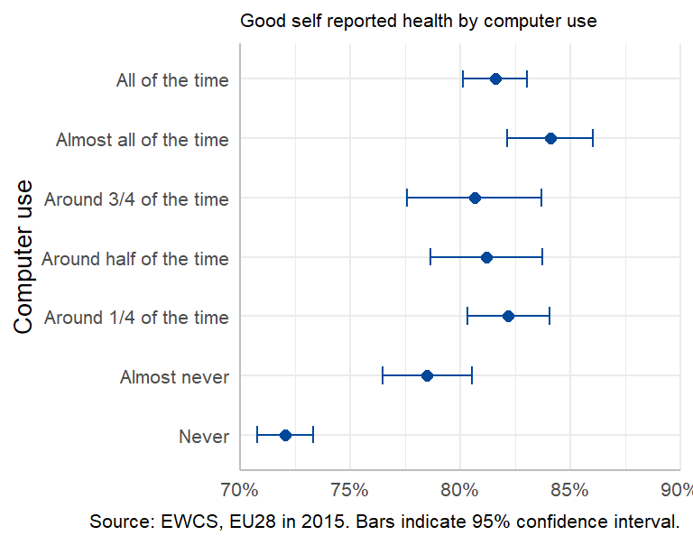

```r
df <- subset(EWCS_EU28, select=c(y15_Q30i,w5_EU28,y15_Q75), year==2015)
df$goodhealth <- as.numeric(df$y15_Q75=="Very good                   " | df$y15_Q75=="Good                        ")

svydes <- svydesign(ids=~1, data=df, weights=~w5_EU28)

df1 <- svyby(~goodhealth, ~y15_Q30i, svydes, svymean, na.rm = TRUE)
df1 <- cbind(df1, confint(df1))
df1$value <- df1$goodhealth
df1$variable <- "Good health"
df <- df1[,-2]

p <- ggplot(df, aes(x=y15_Q30i, y=value)) +
      geom_errorbar(aes(ymin=`2.5 %`, ymax=`97.5 %`), width=0.3, colour=EF_blue) +
      geom_point(size=2, colour=EF_blue) +
      scale_y_continuous(expand = c(0, 0), limit = c(0.7,0.9), breaks = seq(0.7, 0.9, 0.05), labels = percent_format(accuracy = 1)) +
      coord_flip() +
      labs(title = "Good self reported health by computer use",
           caption = "Source: EWCS, EU28 in 2015. Bars indicate 95% confidence interval.",
           x="Computer use",
           y=NULL) +
      theme_minimal(base_size = 10) +
      theme(legend.position="bottom",
            axis.line = element_line(colour="grey"),
            plot.title = element_text(size=8))
p
```

```r
ggsave("Good self reported health by computer use.eps",
       plot = p + labs(title=NULL,caption=NULL),
       device = "eps", path="charts/",
       scale = 1, width = 8, height = 5, units = "cm")
write.csv(df, file="charts/Good self reported health by computer use.csv")
```

## Absenteeism and presenteeism

Chart below shows the proportion of workers who report being absent from work due to sick leave or health-related leave at least one day in the past 12 months. Also, it shows presenteeism - working while sick at least once in the past 12 months. Both show a positive correlation with computer use - the more frequent computer use, the more absenteeism as well as presenteeism. Being absent for at least 5 days shows no correlation with computer use.

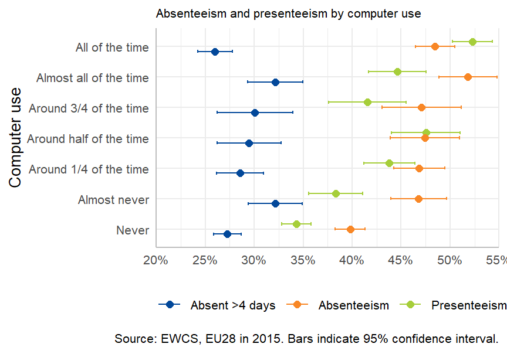

```r
df <- subset(EWCS_EU28, select=c(y15_Q30i,w5_EU28,absenteeism,presenteeism,absent_ESAW), year==2015)
df$abs <- as.numeric(df$absenteeism)-1
df$pre <- as.numeric(df$presenteeism)-1
df$abs5 <- as.numeric(df$absent_ESAW)-1

svydes <- svydesign(ids=~1, data=df, weights=~w5_EU28)

df1 <- svyby(~abs, ~y15_Q30i, svydes, svymean, na.rm = TRUE)
df1 <- cbind(df1, confint(df1))
df1$value <- df1$abs
df1$variable <- "Absenteeism"
df1 <- df1[,-2]

df2 <- svyby(~pre, ~y15_Q30i, svydes, svymean, na.rm = TRUE)
df2 <- cbind(df2, confint(df2))
df2$value <- df2$pre
df2$variable <- "Presenteeism"
df2 <- df2[,-2]

df3 <- svyby(~abs5, ~y15_Q30i, svydes, svymean, na.rm = TRUE)
df3 <- cbind(df3, confint(df3))
df3$value <- df3$abs5
df3$variable <- "Absent >4 days"
df3 <- df3[,-2]

df <- rbind(df1,df2)
df <- rbind(df,df3)

p <- ggplot(df, aes(x=y15_Q30i, y=value, colour=variable)) +
      geom_errorbar(aes(ymin=`2.5 %`, ymax=`97.5 %`), width=0.3, position = position_dodge(width=0.5)) +
      geom_point(size=2, position = position_dodge(width=0.5)) +
      coord_flip() +
      scale_colour_manual(NULL, values=EF_3c) +
      scale_y_continuous(expand = c(0, 0), limit = c(0.2,0.55), breaks = seq(0.2, 0.55, 0.05), labels = percent_format(accuracy = 1)) +
      labs(title = "Absenteeism and presenteeism by computer use",
           caption = "Source: EWCS, EU28 in 2015. Bars indicate 95% confidence interval.",
           x="Computer use",
           y=NULL) +
      theme_minimal(base_size = 10) +
      theme(legend.position="bottom",
            axis.line = element_line(colour="grey"),
            plot.title = element_text(size=8))

p
```

```r
ggsave("Absenteeism and presenteeism by computer use.eps",
       plot = p + labs(title=NULL,caption=NULL),
       device = "eps", path="charts/",
       scale = 1, width = 8, height = 6, units = "cm")
write.csv(df, file="charts/Absenteeism and presenteeism by computer use.csv")
```

## Headaches / eyestrain

Having headaches or eyestrain in the 12 months prior to the survey is reported mroe often by those who use computers. There is quite a linear positive correlation between the two.

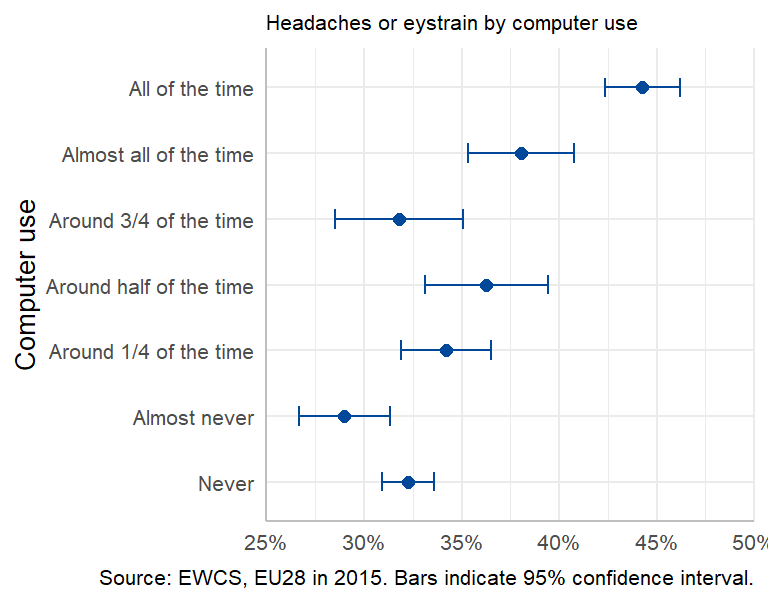

```r
df <- subset(EWCS_EU28, select=c(y15_Q30i,w5_EU28,headeye), year==2015)
df$headache <- as.numeric(df$headeye)-1

svydes <- svydesign(ids=~1, data=df, weights=~w5_EU28)

df1 <- svyby(~headache, ~y15_Q30i, svydes, svymean, na.rm = TRUE)
df1 <- cbind(df1, confint(df1))
df1$value <- df1$headache
df1$variable <- "Headache / eyestrain"
df <- df1[,-2]

p <- ggplot(df, aes(x=y15_Q30i, y=value)) +
      geom_errorbar(aes(ymin=`2.5 %`, ymax=`97.5 %`), width=0.3, colour=EF_blue) +
      geom_point(size=2, colour=EF_blue) +
      coord_flip() +
      scale_y_continuous(expand = c(0, 0), limit = c(0.25,0.50), breaks = seq(0.25, 0.50, 0.05), labels = percent_format(accuracy = 1)) +
      labs(title = "Headaches or eystrain by computer use",
           caption = "Source: EWCS, EU28 in 2015. Bars indicate 95% confidence interval.",
           x="Computer use",
           y=NULL) +
      theme_minimal(base_size = 10) +
      theme(legend.position="bottom",
            axis.line = element_line(colour="grey"),
            plot.title = element_text(size=8))

p
```

```r
ggsave("Headaches or eystrain by computer use.eps",
       plot = p + labs(title=NULL,caption=NULL),
       device = "eps", path="charts/",
       scale = 1, width = 8, height = 5, units = "cm")
write.csv(df, file="charts/Headaches or eystrain by computer use.csv")
```

## Anxiety, stress and fatigue

Chart shows that anxiety and stress are correlated to computer use, but fatigue is not.

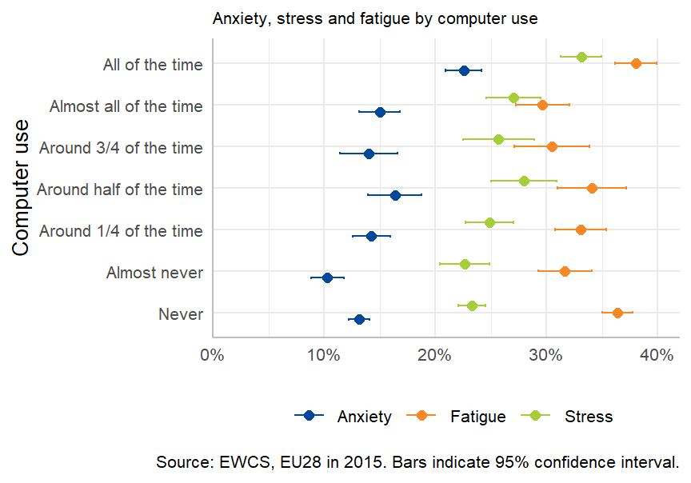

```r
df <- subset(EWCS_EU28, select=c(y15_Q30i,w5_EU28,anxiety,fatigue,stress), year==2015)
df$anxiety <- as.numeric(df$anxiety)-1
df$fatigue <- as.numeric(df$fatigue)-1
df$stress <- as.numeric(df$stress=="Most of the time             " | df$stress=="Always                       ")

svydes <- svydesign(ids=~1, data=df, weights=~w5_EU28)

df1 <- svyby(~anxiety, ~y15_Q30i, svydes, svymean, na.rm = TRUE)
df1 <- cbind(df1, confint(df1))
df1$value <- df1$anxiety
df1$variable <- "Anxiety"
df1 <- df1[,-2]

df2 <- svyby(~fatigue, ~y15_Q30i, svydes, svymean, na.rm = TRUE)
df2 <- cbind(df2, confint(df2))
df2$value <- df2$fatigue
df2$variable <- "Fatigue"
df2 <- df2[,-2]

df3 <- svyby(~stress, ~y15_Q30i, svydes, svymean, na.rm = TRUE)
df3 <- cbind(df3, confint(df3))
df3$value <- df3$stress
df3$variable <- "Stress"
df3 <- df3[,-2]

df <- rbind(df1,df2)
df <- rbind(df,df3)

p <- ggplot(df, aes(x=y15_Q30i, y=value, colour=variable)) +
      geom_errorbar(aes(ymin=`2.5 %`, ymax=`97.5 %`), width=0.2, position = position_dodge(width=0.5)) +
      geom_point(size=2, position = position_dodge(width=0.5)) +
      coord_flip() +
      scale_colour_manual(NULL, values=EF_3c) +
      scale_y_continuous(expand = c(0, 0), limit = c(0,0.42), breaks = seq(0, 0.4, 0.1), labels = percent_format(accuracy = 1)) +
      labs(title = "Anxiety, stress and fatigue by computer use",
           caption = "Source: EWCS, EU28 in 2015. Bars indicate 95% confidence interval.",
           x="Computer use",
           y=NULL) +
      theme_minimal(base_size = 10) +
      theme(legend.position="bottom",
            axis.line = element_line(colour="grey"),
            plot.title = element_text(size=8))

p
```

```r
ggsave("Anxiety, stress and fatigue by computer use.eps",
       plot = p + labs(title=NULL,caption=NULL),
       device = "eps", path="charts/",
       scale = 1, width = 8, height = 6, units = "cm")
write.csv(df, file="charts/Anxiety, stress and fatigue by computer use.csv")
```

## Overall reliability check

Most of the latent variables mentioned above cannot be identified in isolation. They can, however, if they are inlcuded in a larger structure. The output below shows that overall the fit as well as the reliabilty looks good (omega >0.7) except for the reliability of the congnitive dimension.

```r
model <-   'QD   =~ y15_Q49a + y15_Q49b
            AUT  =~ y15_Q54a + y15_Q54b + y15_Q54c
            CD   =~ y15_Q53c + y15_Q53e + y15_Q53f
            SS   =~ y15_Q61a + y15_Q61b
            WHO5 =~ y15_Q87a + y15_Q87b + y15_Q87c + y15_Q87d + y15_Q87e '

fit <- sem(model,data=subset(EWCS_EU28,year>=2010))
fitmeasures(fit,fit.measures=c("tli","cfi","rni","rmsea"))
```

```
##   tli   cfi   rni rmsea
## 0.993 0.995 0.995 0.039
```

```r
reliability(fit)
```

```
##               QD       AUT        CD        SS      WHO5     total
## alpha  0.8132453 0.8968442 0.7855226 0.7916914 0.9029305 0.7730781
## omega  0.7844164 0.7554623 0.6389969 0.7466043 0.8801486 0.8463621
## omega2 0.7844164 0.7554623 0.6389969 0.7466043 0.8801486 0.8463621
## omega3 0.7844164 0.7544798 0.6442024 0.7466043 0.8833245 0.8505030
## avevar 0.6877916 0.7450235 0.5640239 0.6578218 0.6569089 0.6601942
```

# Structural model

## Model estimation

Creating a variable that is the interaction between the year 2015 and computer use. This should reflect the change in the question and control the other coefficients for that effect. Its equal to computer in 2015, and zero otherwise.

```r
EWCS_EU28$comp15 <- EWCS_EU28$computer*EWCS_EU28$w2015
```

The actual definition of the model in R is hidden because of the amount of text.

## Model fit

From SEM course by Bollen:

- TLI should be >.9 and not too much above 1
- CFI should be >.9 and not too much above 1
- RNI should be >.9 and not too much above 1
- RMSEA should be <0.05. 0.05-0.08 is OK fit and >0.10 is bad fit
- BIC should be < 0. BIC differnence between 0-2: weak evidence, 2-6 is positive, 6-10 strong and >10 very strong

Note: BIC can’t be computed with DWLS estimator

The model fit is very good.

```r
fitmeasures(fit1,fit.measures=c("tli","cfi","rni","rmsea"))
```

```
##   tli   cfi   rni rmsea
## 0.995 0.989 0.989 0.021
```

## Results

The first plot below shows the total direct and indirect (mediated) effect of computer use. The sum of the two would be the total effect. Generally the effect of computer use is unfavourable for the health and wellbeing outcomes, although there is no effect for WHO5, and small effects for self-rated health and absenteeism. Interestingly, the positive effect of computer use on presenteeism is much larger than the effect on absenteeism. This might support the hypothesis that digital work is more prone to presenteeism, i.e. its easier to work while sick the more work is done on a computer.

The direct negative effect of computer use on fatigue is almost as big as the positive indirect effect through the job demands and resources. Adding these up hardly leaves any total effect. It is not clear, however, what this reflects. It signals selection effects, i.e. despite controls for personal characteristics and occupational groups perhaps those who have are less fatigued tend to use computers more often. Alternatively or additionally, it could also reflect any positive effects of ICT use on job resources not included in the model.

The strong direct effect of ICT use and headache / eyestrain is to be expected. This may reflect the effect of computers that is not mediated through the other variables; headaches and eyestrain from looking at a screen for example.

Ter Hoeven et al (2016) find no direct effects of computer use on engagement and burnout, but find evidence for a fully mediated model. Chesley (2014) does find some direct negative effects of ICT use on stress after controlling for the mediation through working at high speed, interruptions and multitasking.

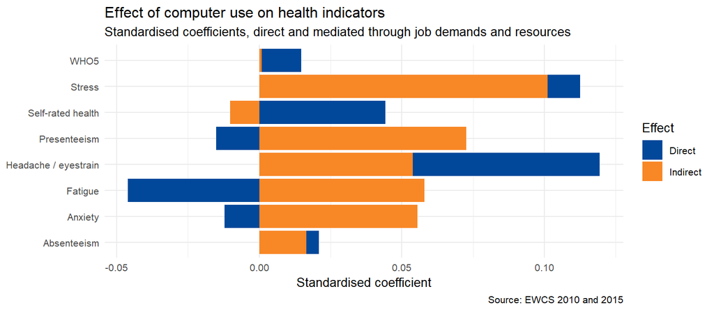

The plot below shows the indirect effect of computer use by mediator and by outcome variable. This is thus limited to the effect of computer use mediated through the job demands and resources. Looking under the hood we can see that for most indicators the overall indirect effect is the aggregate of both positive and negative effects. This illustrates that the effect of ICT on health is both positive and negative at the same time. Frequent disruptive interruptions, the cognitive dimension and quantitative demands seem to have the strongest effect on health outcomes. ICT works through the mediators more selectively.

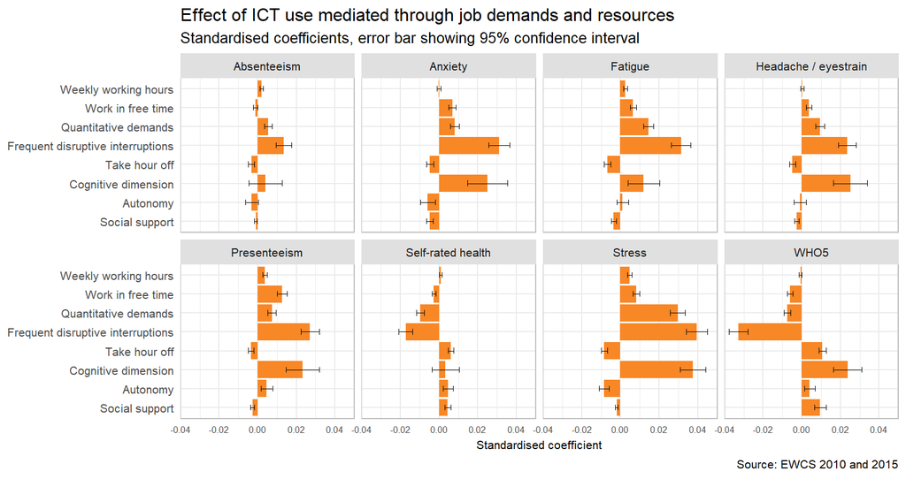

The next plot shows the effect of the mediator variable on the outcomes in general, regardless of computer use. All variables are of similar size, except for the effects of autonomy. The indicators behave as expected: job resources have a positive effect and job demands a negative effect, supporting the JD-R theory. The exception is the cognitive dimension. The cognitive dimension has a negative connotation, which may reflect the increased responsibility or cognitive demands that come with that.

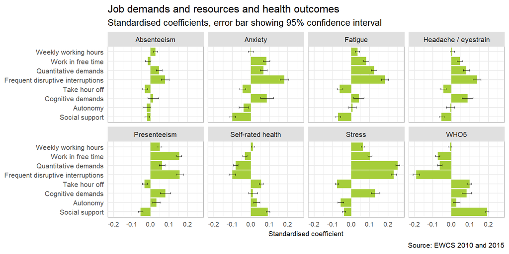

# Model with ICT mobile workers

This model takes structural model 1, but then replaces ICT use with the categories of ICT mobile workers. So we are hypothesising that ICT mobile worker categories have an effect on mediators, which in trun have an effect on health outcomes. Also, we hypothesise a direct effect of ICT mobile worker on health in addition.

```r
#EWCS_EU28$alwaysoffice_1 <- as.numeric((EWCS_EU28$cat_ictmob=="Always Office, self-employed" & EWCS_EU28$computer<=5) | EWCS_EU28$cat_ictmob=="Always at employers premise w/o ICT, employee")
#EWCS_EU28$alwaysofficeICT_1 <-  as.numeric(EWCS_EU28$cat_ictmob=="Always at employers premise with ICT, employee")
#EWCS_EU28$teleworker_1 <- as.numeric(EWCS_EU28$cat_ictmob=="Home-based teleworker, employee")
#EWCS_EU28$highmob_1 <- as.numeric(EWCS_EU28$cat_ictmob=="High mobile T/ICTM, employee")
#EWCS_EU28$lowmob_1 <- as.numeric( EWCS_EU28$cat_ictmob=="Occasional T/ICTM, employee")
#EWCS_EU28$selfICTM <- as.numeric((EWCS_EU28$cat_ictmob=="Always Office, self-employed" & EWCS_EU28$computer>5) | EWCS_EU28$cat_ictmob=="Home-based ICT, self-employed" | EWCS_EU28$cat_ictmob=="High mobile ICT, self-employed" | EWCS_EU28$cat_ictmob=="Low-mobile ICT, self-employed" )

EWCS_EU28$alwaysoffice_1 <- as.numeric(EWCS_EU28$TICTM2=="Always at employers premise w/o ICT, employee")
EWCS_EU28$alwaysofficeICT_1  <- as.numeric(EWCS_EU28$TICTM2=="Always at employers premise with ICT, employee" )
EWCS_EU28$teleworker_1  <- as.numeric(EWCS_EU28$TICTM2=="Home-based teleworker, employee" )
EWCS_EU28$highmob_1  <- as.numeric(EWCS_EU28$TICTM2=="High mobile T/ICTM, employee")
EWCS_EU28$lowmob_1 <- as.numeric( EWCS_EU28$TICTM2=="Occasional T/ICTM, employee")
EWCS_EU28$self_alwaysoffice <- as.numeric(EWCS_EU28$TICTM2=="Self-employed")
EWCS_EU28$selfICTM <- as.numeric(EWCS_EU28$TICTM2=="Self-employed T/ICTM")
```

## Model fit

Model fit is good.

```r
fitmeasures(fit9,fit.measures=c("tli","cfi","rni","rmsea"))
```

```
##   tli   cfi   rni rmsea
## 0.995 0.989 0.989 0.021
```

## Results

The figure below shows the effect of all ICT mobile worker categories taken together relative to the reference category ‘other’. Generally the picture looks similar to the chart of the model that was just based on computer use.

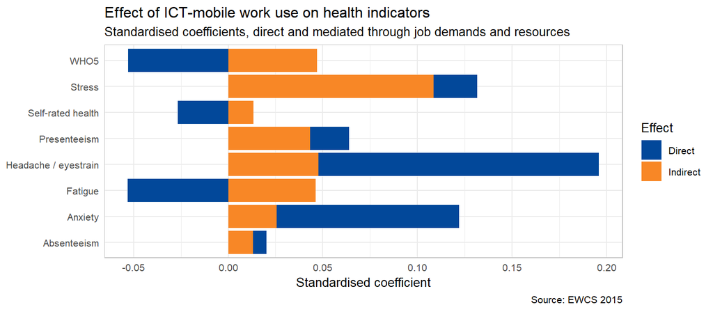

This chart breaks it down by the different groups

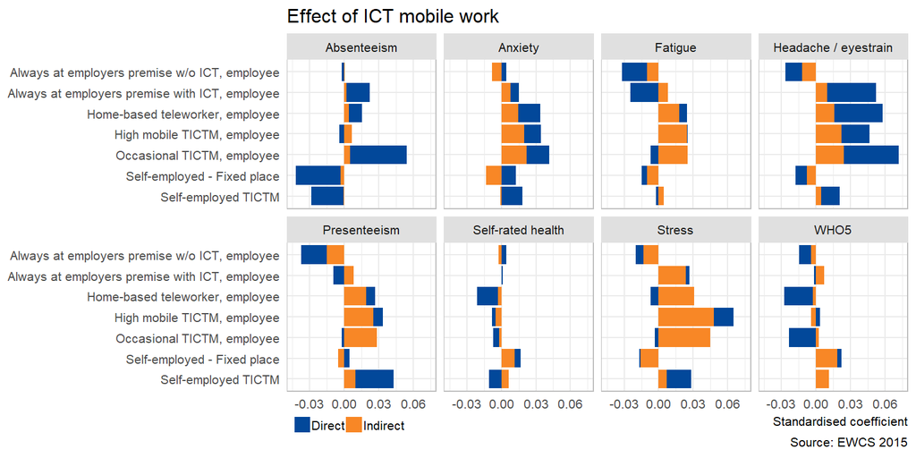

Chart below shows the indirect effects of the groups taken together, by their mediation variables.

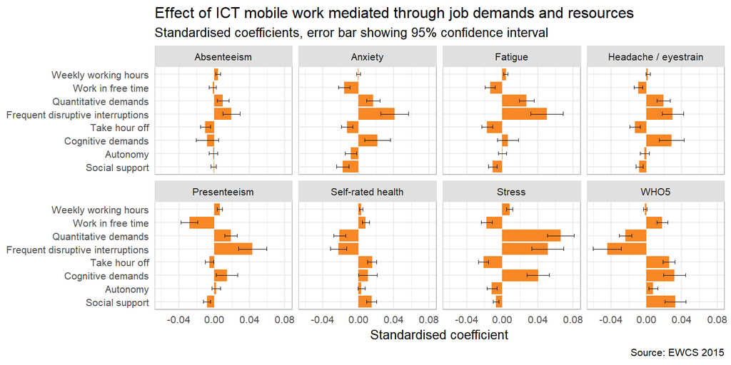

# Literature

- Berg-Beckhoff, G., Nielsen, G., & Ladekjær Larsen, E. (2017). Use of information communication technology and stress, burnout, and mental health in older, middle-aged, and younger workers–results from a systematic review. International journal of occupational and environmental health, 23(2), 160-171.
- Bollen, K. A. and Pearl, J. (2013), ‘Eight myths about causality and structural equation models’, in Morgan, S.L. (ed.), Handbook of causal analysis for social research, Springer, New York, pp. 301–328.
- Charalampous, M., Grant, C. A., Tramontano, C., & Michailidis, E. (2018). Systematically reviewing remote e-workers’ well-being at work: a multidimensional approach. European Journal of Work and Organizational Psychology, 1-23.
- Chesley, N. (2014). Information and communication technology use, work intensification and employee strain and distress. Work, employment and society, 28(4), 589-610.
- Eurofound (2017), Sixth European Working Conditions Survey – Overview report (2017 update), Publications Office of the European Union, Luxembourg.
- Eurofound (2019), Working conditions and workers’ health and well-being, Publications Office of the European Union, Luxembourg.
- Green, F. (2004). Why has work effort become more intense?. Industrial Relations: A Journal of Economy and Society, 43(4), 709-741.
- Salanova, M., Llorens, S., & Cifre, E. (2013). The dark side of technologies: Technostress among users of information and communication technologies. International journal of psychology, 48(3), 422-436.
- Stadin, M., Nordin, M., Broström, A., Hanson, L. L. M., Westerlund, H., & Fransson, E. I. (2016). Information and communication technology demands at work: the association with job strain, effort-reward imbalance and self-rated health in different socio-economic strata. International archives of occupational and environmental health, 89(7), 1049-1058.
- Ter Hoeven, C. L., van Zoonen, W., & Fonner, K. L. (2016). The practical paradox of technology: The influence of communication technology use on employee burnout and engagement. Communication monographs, 83(2), 239-263.